# PSYCH 260

2020-09-14 08:06:35

## Pre-check

- Mic on
- Zoom share screen, set sound output
- 2nd computer connect to Zoom
- Projector on

## How to play EyeWire (03:56)

[video not shown]

http://eyewire.org

## Announcements

- Exam 1 next Thursday, 9/24
  - 40 questions
- Complete 1 “component/section” in EyeWire, earn 5 extra credit points.
  - Take screen shot, email to Shekoo
  - Due before Friday, 10/16

## Today’s Topics

- Cells of the nervous system
  - *Glia*
  - *Neurons*
- How do these cells communicate?

## Could you count to 170 billion?

- How many years to count to 170 billion?
- 60 s/min x 60 min/hr x 24 hrs/day x 365 days/ yr = 31,536,000 s/yr
- 1.7e11/31,536,000 = 5,390 years

## Mass, Neurons, Non-Neurons

[figure not shown]

[(Azevedo et al., 2009)](http://doi.org/10.1002/cne.21974)

## Neurons by brain mass

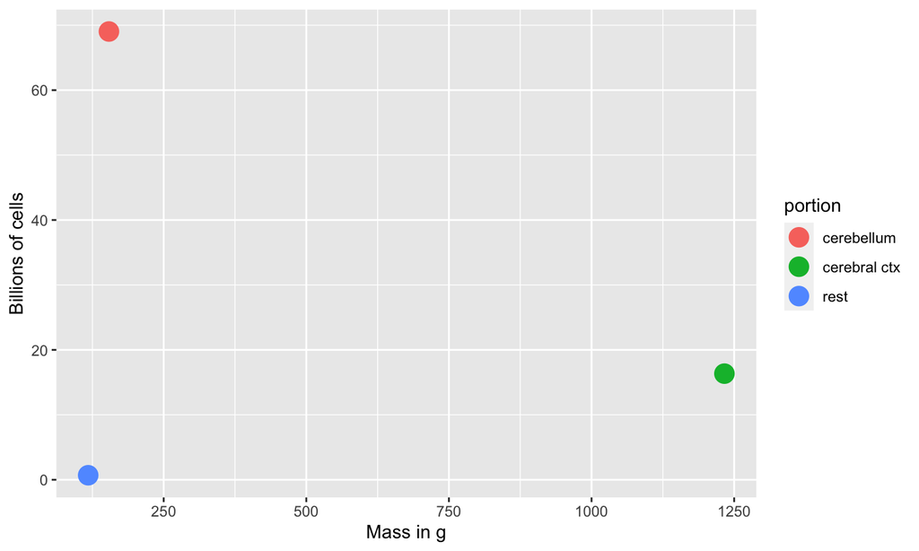

## Non-neuronal cells by brain mass

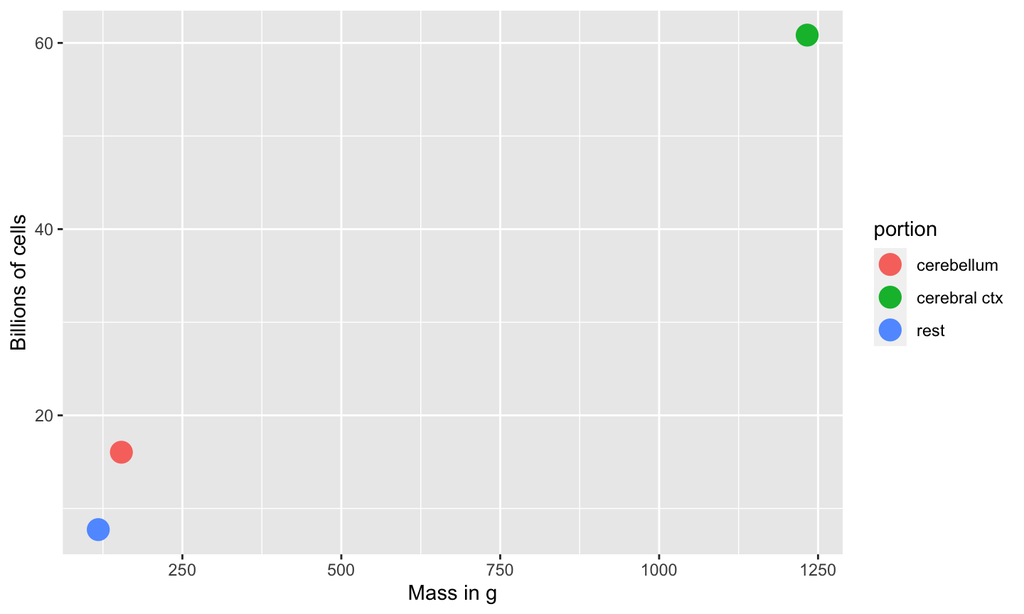

## How many neurons and glia?

*“These findings challenge the common view that humans stand out from other primates in their brain composition and indicate that, with regard to numbers of neuronal and nonneuronal cells, the human brain is an isometrically scaled-up primate brain.”*

[(Azevedo et al., 2009)](http://doi.org/10.1002/cne.21974)

## The Human Advantage

[figure not shown]

## Glia (neuroglia)

- “Glia” means glue
- Functions
  - Structural support
  - Metabolic support
  - Brain development
  - Neural plasticity?

## Astrocytes

- “Star-shaped”
- Physical and metabolic support
  - Blood/brain barrier
  - Regulate concentration of key ions (Ca++/K+) for neural communication
  - Regulate concentration of key neurotransmitters (e.g., glutamate)

## Astrocytes

- Shape brain development, [synaptic plasticity](https://en.wikipedia.org/wiki/Synaptic_plasticity)
- Regulate local blood flow
- Regulate/influence communication between neurons, [(Bazargani & Attwell, 2016)](http://doi.org/10.1038/nn.4201)
- Disruption linked to cognitive impairment, disease [(Chung, Welsh, Barres, & Stevens, 2015)](http://doi.org/10.1038/nn.4142)

## Astrocytes

[figure not shown]

## Myelinating cells

- Produce [myelin](https://en.wikipedia.org/wiki/Myelin) or myelin sheath
  - White, fatty substance
  - Surrounds many neurons
  - The “white” in white matter
- Provide electrical/chemical insulation
- Make neuronal messages faster, less susceptible to noise

## Types of myelin-producing cells

- [Oligodendrocytes](https://en.wikipedia.org/wiki/Oligodendrocyte)
  - In brain and spinal cord (CNS)
  - 1:many neurons
- [Schwann cells](https://en.wikipedia.org/wiki/Schwann_cell)
  - In PNS
  - 1:1 neuron
  - Facilitate neuro-regeneration

## Oligodendrocytes

[figure not shown]

## Schwann Cells

[figure not shown]

## Microglia

- Phagocytosis
- Clean-up damaged, dead tissue
- Prune synapses in normal development and disease
- Disruptions in microglia pruning -> impaired functional brain connectivity and social behavior, [(Zhan et al., 2014)](http://doi.org/10.1038/nn.3641)

## Microglia

[figure not shown]

## [Neurons](https://en.wikipedia.org/wiki/Neuron)

[figure not shown]

## Macrostructure of [neurons](https://en.wikipedia.org/wiki/Neuron)

- [Dendrites](https://en.wikipedia.org/wiki/Dendrite)
- Soma (cell body)
- [Axons](https://en.wikipedia.org/wiki/Axon)
- [Terminal buttons (boutons)](https://en.wikipedia.org/wiki/Axon_terminal)

## Structure of neurons

[figure not shown]

## [Dendrites](https://en.wikipedia.org/wiki/Dendrite)

- Branch-like “extrusions” from cell body
- Majority of input to neuron
- Cluster close to cell body/soma
- Usually receive info
- Passive (do not regenerate electrical signal) vs. active (regenerate signal)
- Spines

## [Dendrites](https://en.wikipedia.org/wiki/Dendrite)

[figure not shown]

## Dendritic Spines

[figure not shown]

## Soma (cell body)

- Varied shapes
- Nucleus
  - Chromosomes
- Organelles
  - Mitochonrdria
  - Smooth and Rough Endoplasmic reticulum (ER)

## Soma

[figure not shown]

## [Axons](https://en.wikipedia.org/wiki/Axon)

- Another branch-like “extrusion” from soma
- Extend farther than dendrites
- Usually transmit info

## [Axons](https://en.wikipedia.org/wiki/Axon)

- Parts
  - **Initial segment** (closest to soma, unmyelinated)
  - **Nodes of Ranvier** (unmyelinated segments along axon)
  - Terminals, axon terminals, terminal buttons, synaptic terminals, synaptic boutons

## Axons

[figure not shown]

## [Synaptic bouton (terminal button)](https://en.wikipedia.org/wiki/Axon_terminal)

- [Synapse](https://en.wikipedia.org/wiki/Chemical_synapse#Structure) (~5-10K per neuron)
- Presynaptic membrane (sending cell) and postsynaptic (receiving cell) membrane
- Synaptic cleft – space between cells
- [Synaptic vesicles](https://en.wikipedia.org/wiki/Synaptic_vesicle)
  - Pouches of neurotransmitters
- [Autoreceptors](https://en.wikipedia.org/wiki/Autoreceptor) (detect NTs); [transporters](https://en.wikipedia.org/wiki/Neurotransmitter_transporter) (transport NTs across membrane)

## [Synaptic bouton (terminal button)](https://en.wikipedia.org/wiki/Axon_terminal)

[figure not shown]

## Classifying neurons

- Functional role
  - Input (sensory), output (motor/secretory), interneurons
- Anatomy
  - Unipolar
  - Bipolar
  - Multipolar

[figure not shown]

https://upload.wikimedia.org/wikipedia/commons/thumb/9/92/Neurons_uni_bi_multi_pseudouni.svg/2000px-Neurons_uni_bi_multi_pseudouni.svg.pngg

## Classifying neurons

- By specific anatomy
  - Pyramidal cells
  - Stellate cells
  - Purkinje cells
  - Granule cells

## Neurons by type

[figure not shown]

## How neurons communicate

## Neural communication

- Electrical
  - Fast(er)
  - Metabolically costly
  - Within neurons

## Neural communication

- Chemical
  - Slow(er)
  - Metabolically cheap
  - Between neurons, & brain <-> body (via hormones)

## How are messages generated?

- Electrical potential (== voltage)
  - Think of potential energy
  - Voltage ~ pressure
  - Energy that will be released if something changes

## Potential energy

[figure not shown]

## Types of neural electrical potentials

- [Resting potential](https://en.wikipedia.org/wiki/Resting_potential)
- [Action potential](https://en.wikipedia.org/wiki/Action_potential)

## [Resting potential](https://en.wikipedia.org/wiki/Resting_potential)

- How to measure
  - Electrode on inside
  - Electrode on outside
  - Inside - Outside = potential

## [Resting potential](https://en.wikipedia.org/wiki/Resting_potential)

[figure not shown]

## [Resting potential](https://en.wikipedia.org/wiki/Resting_potential)

- Neuron (and other cells) have *potential energy*
  - Inside neuron is -60-70 mV, with respect to outside
  - About 1/20th typical AAA battery
- Like charges repel, opposites attract, so
  - Positively charged particles pulled in
  - Negatively charged particles pushed out

## Where does the resting potential come from?

- Ions
- Ion channels
- Separation between charges
- A balance of forces

## We are the champIONs, my friend

- Potassium, K+
- Sodium, Na+
- Chloride, Cl-
- Organic anions, A-

## Resting potential arises from

- A balance of forces
  - Force of diffusion
  - Electrostatic force
- Forces cause ion flows across membrane
- Ion channels allow ion flow

## Ion channels

- Openings in neural membrane
- Selective
- Vary in permeability

## Ion channel Types

- *Passive/leak*
  - Always open
- *Voltage-gated*
  - Open/close at certain voltages
- *Ligand-gated* (chemically-gated)
  - Open/close in presence of special chemicals (ligands)
- Transporters/pumps
  - Move (transport/pump) ions using metabolic energy

## Ion channels

[figure not shown]

## Neuron at rest permeable to K+

- Passive K+ channels open
- [K+] concentration inside >> outside
- K+ flows out

## Force of diffusion

[figure not shown]

## Force of diffusion

[figure not shown]

## Neuron at rest permeable to K+

- Organic anions (A-) too large to move outside of cell
- A- and K+ largely in balance == no net internal charge
- K+ outflow creates charge separation: K+ <-> A-
- Charge separation creates a voltage
- Outside +/inside -
- Voltage build-up stops outflow of K+ (before inside/outside concentrations are ==)

## The resting potential

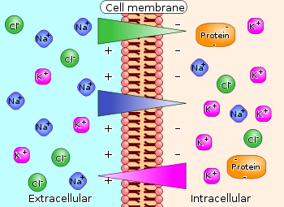

## Balance of forces in the neuron at rest

- **Force of diffusion**
  - K+ moves from high concentration (inside) to low (outside)

## Balance of forces in the neuron at rest

- **Electrostatic force**
  - Positive K+ accumulate along outside
  - Negative A- accumulate along inside
  - K+ || A- along membrane creates battery-like voltage
  - Voltage build-up stops K+ outflow

## Electrostatic force

- Specific voltage called *equilibrium potential* for K+
- K+ positive, so equilibrium potential negative (w/ respect to outside)
- Equilibrium potential close to neuron resting potential

## [Equilibrium potentials calculated](http://www.physiologyweb.com/calculators/nernst_potential_calculator.html) under typical conditions

[output not shown]

[figure not shown]

## Electrical circuit model

[figure not shown]

## Resting potential ≠ K+ [equilibrium potential](https://courses.washington.edu/conj/membpot/equilpot.htm)

- Resting potential not just due to K+ flow
- Other ions flow
- Resting potential == net effects of all ion flows across membrane

## Next time

- More on neural communication
- What are the other ions doing?

## References

Azevedo, F. A., Carvalho, L. R., Grinberg, L. T., Farfel, J. M., Ferretti, R. E., Leite, R. E., … others. (2009). Equal numbers of neuronal and nonneuronal cells make the human brain an isometrically scaled-up primate brain. *Journal of Comparative Neurology*, *513*(5), 532–541.

Bazargani, N., & Attwell, D. (2016). Astrocyte calcium signaling: The third wave. *Nature Neuroscience*, *19*(2), 182–189. https://doi.org/10.1038/nn.4201

Bhardwaj, R. D., Curtis, M. A., Spalding, K. L., Buchholz, B. A., Fink, D., Björk-Eriksson, T., … Frisén, J. (2006). Neocortical neurogenesis in humans is restricted to development. *Proceedings of the National Academy of Sciences*, *103*(33), 12564–12568. https://doi.org/10.1073/pnas.0605177103

Chung, W.-S., Welsh, C. A., Barres, B. A., & Stevens, B. (2015). Do glia drive synaptic and cognitive impairment in disease? *Nature Neuroscience*, *18*(11), 1539–1545. https://doi.org/10.1038/nn.4142

Magrassi, L., Leto, K., & Rossi, F. (2013). Lifespan of neurons is uncoupled from organismal lifespan. *Proceedings of the National Academy of Sciences*, *110*(11), 4374–4379. https://doi.org/10.1073/pnas.1217505110

Zhan, Y., Paolicelli, R. C., Sforazzini, F., Weinhard, L., Bolasco, G., Pagani, F., … Gross, C. T. (2014). Deficient neuron-microglia signaling results in impaired functional brain connectivity and social behavior. *Nature Neuroscience*, *17*(3), 400–406. https://doi.org/10.1038/nn.3641